Stephen Dillon 800893698

Anthropic's Claude AI Models Sonnet 5 and Opus 5.5 were used to assist with this project

# Project 2: Machine Learning and Home Loan Data

## Problem and Dataset

Given the current economic environment and the focus on interest rates and housing, I'm curious about what elements inform whether someone is approved for a mortgage loan.

In particular, I'm curious what elements inform whether an applicant, who is a typical homeowner, is approved for refinancing. If they are approved, for what amount?

The data set I am using is mortgage application data provided by the Consumer Financial Protection Bureau (CFPB), specifically for North Carolina in 2017.

Using data specifically for North Carolina helps control for different housing markets and lending laws across states, and North Carolina's demographic diversity helps in testing demographic bias in loan approval. Also I am interested in the market for North Carolina as it's my home state.

As 2017 was a fairly stable year economically compared to today I believe it can serve as a test case for a healthy market. This data can then be used to gauge current market conditions or shifts in what elements lead to loan approval and amount. Refinancing tends to have lower approval rate and can give insights into the economic health of homeowners.

The first step in modeling will be a classification task, determining the likelihood of a refinancing loan being approved for a first lien, owner occupied, 1-4 family dwelling. The second step in modeling will be a regression task, determining the amount the loan is approved for.

**Dataset source:** [CFPB Home Mortgage Disclosure Act data (HMDA)](https://www.consumerfinance.gov/data-research/hmda/historic-data/?geo=nc&records=all-records&field_descriptions=labels)

- Field values: “Geographic area” = North Carolina, “Records included” = “All Records”, and “Variable descriptions” = “Plain language labels and HMDA codes”, year is 2017
  - Plain datasets with only HMDA codes unavailable at time of writing.

## Variables and Dataset Characteristics

### **Targets**

- Loan approval and loan ammount (in thousands USD)
- `action_taken` single-hot encoded, `loan_amount_000s` log-transformed

`action_taken` encoding table for classification testing:

| `action_taken_name` | Target (`approved`) | Reason |
| --- | --- | --- |
| Loan originated | 1 (approved) | The lender approved the loan and it was made. |
| Application approved but not accepted | 1 (approved) | The lender approved the loan, but the applicant chose not to accept it. |
| Application denied by financial institution | 0 (denied) | The lender denied the application. |
| Application withdrawn by applicant | Dropped | The applicant withdrew before a decision was made. |
| File closed for incompleteness | Dropped | The application was closed before a decision was made. |
| Loan purchased by the institution | Dropped | The loan was bought from another lender; no approval decision was made by this institution. |
| Preapproval request denied by financial institution | Dropped | A preapproval request, not a full loan application. |
| Preapproval request approved but not accepted | Dropped | A preapproval request, not a full loan application. |

### **Controlled Features**

These features are constants use to filter the data. They are matched to their corresponding numerical HMDA code fields.

| Controlled feature | Field name | Fixed value | Why it's held constant |
| --- | --- | --- | --- |
| Loan purpose | `loan_purpose_name` | Refinancing | Refinance decisions follow different rules than home purchases or home improvement loans. |
| Lien status | `lien_status_name` | Secured by a first lien | Excludes riskier second mortgages and unsecured loans. |
| Occupancy | `owner_occupancy_name` | Owner-occupied as a principal dwelling | Excludes investment properties and second homes, which are underwritten differently. |
| Property type | `property_type_name` | One-to-four family dwelling (other than manufactured housing) | Excludes manufactured housing (often personal-property loans) and multifamily (commercial) loans. |

### **Tested Features**

#### 1. Applicant financial capacity

| Feature | Field name(s) in dataset | Preperation | Evidence from the data |
| --- | --- | --- | --- |
| Applicant income | `applicant_income_000s` | Log-transform; fill missing values with the median | Approval rises from 56.8% in the lowest income fifth (≤$40K) to 81.9% in the highest (>$116K). This is the single strongest predictor. |
| Loan-to-income ratio | `loan_amount_000s` / `applicant_income_000s` = `loan_to_income` | Divide loan amount by income (a stand-in for debt-to-income) | Steady at 72–77% until the highest fifth (above 3.6× income), where approval drops to 58.9%. |
| Income missing flag | `applicant_income_000s` -> `income_missing` | 1 if income is blank, else 0 | 83.2% approved vs. 71.7% (signals streamline refinances). |
| Co-applicant present | `co_applicant_sex_name` -> `has_coapplicant` | 1 if not "No co-applicant," else 0 | 77.3% approved with a co-applicant vs. 70.1% without. |

#### 2. Loan characteristics

| Feature | Field name(s) in dataset | Preperation | Evidence from the data |
| --- | --- | --- | --- |
| Loan type | `loan_type_name` | One-hot encode | Conventional 76.7%; VA 67.6%; FHA 65.4%. |
| Loan amount | `loan_amount_000s` | Log-transform | Larger loans are approved somewhat more often, likely because they go to higher-income borrowers. |

#### 3. Lender

| Feature | Field name(s) in dataset | Preperation | Evidence from the data |
| --- | --- | --- | --- |
| Regulating agency | `agency_name` | One-hot encode | Ranges from 70.4% (HUD-regulated lenders, mostly nonbank mortgage companies) to 85.0% (Federal Reserve–regulated banks). |

#### 4. Location and neighborhood

| Feature | Field name(s) in dataset | Preperation | Evidence from the data |
| --- | --- | --- | --- |
| Metro vs. non-metro | `msamd_name` -> `metro_area` | 1 if present, else 0 | 74.0% metro vs. 68.3% non-metro. |
| Tract income relative to metro median | `tract_to_msamd_income` | Numeric; drop the 125 rows missing tract data | Higher-income neighborhoods have higher approval. |
| Tract owner-occupancy rate | `number_of_owner_occupied_units` / `number_of_1_to_4_family_units` = `tract_owner_occ_rate` | Divide owner-occupied units by 1–4 family units | Higher homeownership areas have higher approval. |
| HUD median family income | `hud_median_family_income` | Numeric (in dollars, not thousands) | Area-level income context. |
| Minority population % | `minority_population` | Numeric | Higher-minority tracts have lower approval. |

### **Missing Values**

| Column | Missing | % missing | What it means |
| --- | --- | --- | --- |
| `msamd_name` (metro area) | 15,251 | 16.2% | Missing not at Random: The property is outside a metro area. Recoded as "Non-metro." |
| `applicant_income_000s` | 10,779 | 11.5% | Missing at Random: Mostly from streamline refinances where income wasn't considered, related to `loan_type` and `agency_name`. Filled with the median and added an `income_missing` flag. See note below… |
| Census tract fields (tract income, minority %, population, HUD median income, housing units) | 125 | 0.13% | only 0.13% missing. Dropped |
| `county_name` | 121 | 0.13% | Only 0.13% missing. Nearly the same rows as the tract fields above. Dropped |
| Loan amount, loan type, agency, lien/occupancy/property, outcome | 0 | 0% | Complete. |

`applicant_income_000s` Note: HMDA rules exempt lenders from reporting income when it wasn’t considered in the credit decision. Generally affects refinancing loans, and generally government loans as they didn’t need income verification (VA, FSA/RHS, and FHA loans)

### **Dropped Features**

#### Fields dropped before modeling

| Field(s) | Reason | Explanation |
| --- | --- | --- |
| `denial_reason_1` through `denial_reason_3`, `denial_reason_name_1` through `denial_reason_name_3` | Leakage | Only filled in for denied applications, so they reveal the outcome. |
| `rate_spread` | Leakage | Only reported for originated higher-priced loans, so it is only known after approval. |
| `hoepa_status`, `hoepa_status_name` | Leakage | Describes the terms of a loan that was made, so it is only known after approval. |
| `purchaser_type`, `purchaser_type_name` | Leakage | Records who bought the loan after it was made. |
| `respondent_id` | Identifier | Lender ID with no meaningful predictive information; could let the model memorize individual lenders. |
| `sequence_number`, `edit_status`, `edit_status_name`, `application_date_indicator` | Empty | Blank for every record in the 2017 public data. |
| `as_of_year` | Constant | Every record is from 2017. |
| `state_name`, `state_abbr`, `state_code` | Constant | Every record is in North Carolina. |
| `loan_purpose`, `loan_purpose_name` | Constant after filtering | Every record is a refinance. |
| `lien_status`, `lien_status_name` | Constant after filtering | Every record is a first lien. |
| `owner_occupancy`, `owner_occupancy_name` | Constant after filtering | Every record is owner-occupied. |
| `property_type`, `property_type_name` | Constant after filtering | Every record is a 1–4 family site-built home. |
| `preapproval`, `preapproval_name` | Constant after filtering | Always "Not applicable" for refinances. |
| `action_taken`, `loan_type`, `agency_code`, `agency_abbr`, `msamd`, `co_applicant_sex`, `applicant_sex`, `applicant_ethnicity`, `applicant_race_1` | Duplicate code | Numeric or abbreviated versions of `_name` fields that are already used. |
| `applicant_race_2` through `applicant_race_5`, `applicant_race_name_2` through `applicant_race_name_5` | Mostly empty | 99%+ blank; only the first race field is used. |
| `co_applicant_race_1` through `co_applicant_race_5`, `co_applicant_race_name_1` through `co_applicant_race_name_5`, `co_applicant_ethnicity`, `co_applicant_ethnicity_name` | Not used | Co-applicant demographics aren't part of the analysis; co-applicant presence is captured by `has_coapplicant`. |
| `county_name`, `county_code`, `census_tract_number` | Too granular | Hundreds of categories, some with very few applications, which invites overfitting; location is captured by the metro and tract features. |
| `population` | Weak predictor | Essentially no relationship with approval in this data. |

#### Fields dropped after feature engineering

| Field | Used to create |
| --- | --- |
| `action_taken_name` | `approved` (target) |
| `co_applicant_sex_name` | `has_coapplicant` |
| `msamd_name` | `metro_area` |
| `number_of_owner_occupied_units`, `number_of_1_to_4_family_units` | `tract_owner_occ_rate` |

#### Fields dropped for regression testing

| Field(s) | Reason | Explanation |
| --- | --- | --- |
| `loan_amount_000s` | Target | This is what the model predicts, so it can't be a feature. Log-transform it before modeling. |
| `loan_to_income` (engineered) | Leakage | Calculated from the loan amount, so it contains the answer. |
| `approved` (engineered) | Constant | Every row in the regression sample is approved. |
| `action_taken` | Not a feature | Used only to select approved rows; whether the borrower accepted the offer happens after the amount is set. |

#### Fields set aside for the fairness/bias audit (not model features)

| Field | Purpose |
| --- | --- |
| `applicant_race_name_1` | Compare model errors across racial groups |
| `applicant_ethnicity_name` | Compare model errors across ethnic groups |
| `applicant_sex_name` | Compare model errors across sex groups |

## Code

### Imports

```python
# Imports
import pandas as pd
import matplotlib.pyplot as plt
import seaborn as sns
import numpy as np

from sklearn.tree import DecisionTreeClassifier
from sklearn.model_selection import train_test_split, StratifiedKFold, GridSearchCV
from sklearn.compose import ColumnTransformer
from sklearn.pipeline import Pipeline
from sklearn.impute import SimpleImputer
from sklearn.preprocessing import StandardScaler, OneHotEncoder
from sklearn.dummy import DummyClassifier
from sklearn.linear_model import LogisticRegression
from sklearn.ensemble import RandomForestClassifier
from sklearn.inspection import permutation_importance
from sklearn.metrics import (accuracy_score, balanced_accuracy_score, precision_score, recall_score,
                             f1_score, roc_auc_score, roc_curve, ConfusionMatrixDisplay)

# Set display options
pd.set_option("display.max_columns", 50)
pd.set_option("display.float_format", "{:,.3f}".format)
sns.set_theme(style="whitegrid", context="notebook")
plt.rcParams["figure.dpi"] = 110

# Set random state for reproducibility
RANDOM_STATE = 42
```

### Setup, Filtering, and Cleaning

#### **1. Load dataset as dataframe**

```python
# Load data from CSV file into dataframe
df_raw = pd.read_csv("hmda_2017_nc_all-records_labels.csv")

df_raw.head(1)
```

|  | as_of_year | respondent_id | agency_name | agency_abbr | agency_code | loan_type_name | loan_type | property_type_name | property_type | loan_purpose_name | loan_purpose | owner_occupancy_name | owner_occupancy | loan_amount_000s | preapproval_name | preapproval | action_taken_name | action_taken | msamd_name | msamd | state_name | state_abbr | state_code | county_name | county_code | ... | co_applicant_sex | applicant_income_000s | purchaser_type_name | … |
| --- | --- | --- | --- | --- | --- | --- | --- | --- | --- | --- | --- | --- | --- | --- | --- | --- | --- | --- | --- | --- | --- | --- | --- | --- | --- | --- | --- | --- | --- | --- |
| 0 | 2017 | 43-1965151 | Department of Housing and Urban Development | HUD | 7 | VA-guaranteed | 3 | Manufactured housing | 2 | Refinancing | 3 | Owner-occupied as a principal dwelling | 1 | 150 | Not applicable | 3 | Application denied by financial institution | 3 | Winston, Salem - NC | 49,180.000 | North Carolina | NC | 37 | Forsyth County | 67.000 | ... | 2 | 58.000 | Loan was not originated or was not sold in cal... | … |

1 rows × 78 columns

#### **2. Define and load needed columns**

```python
# Set columns to keep for filtering, engineering, and auditing.

# Columns used to filter the sample and build the target (dropped once filtering is done)
FILTER_COLS = [
    "action_taken_name", "loan_purpose_name", "lien_status_name",
    "owner_occupancy_name", "property_type_name",
]
# Features and the source fields for engineered features
FEATURE_SOURCE_COLS = [
    "applicant_income_000s", "loan_amount_000s", "loan_type_name", "agency_name",
    "co_applicant_sex_name", "msamd_name", "tract_to_msamd_income",
    "minority_population", "hud_median_family_income",
    "number_of_owner_occupied_units", "number_of_1_to_4_family_units",
]
# Kept for the fairness audit, not used as features in the main models
FAIRNESS_COLS = ["applicant_race_name_1", "applicant_ethnicity_name", "applicant_sex_name"]

# Columns to keep for filtering, engineering, and auditing
KEEP_COLS = FILTER_COLS + FEATURE_SOURCE_COLS + FAIRNESS_COLS

# Create a new dataframe with only the columns we want to keep
df = df_raw[KEEP_COLS].copy()

df.head(1)
df.shape
```

```
(464109, 19)
```

#### **3. Define and apply target and constant filters**

```python
# Target definition: only applications with an explicit approve/deny decision
OUTCOME_MAP = {
    "Loan originated": 1,
    "Application approved but not accepted": 1,
    "Application denied by financial institution": 0,
}

# Controlled (held-constant) sample filters
SAMPLE_FILTERS = {
    "loan_purpose_name": "Refinancing",
    "lien_status_name": "Secured by a first lien",
    "owner_occupancy_name": "Owner-occupied as a principal dwelling",
    "property_type_name": "One-to-four family dwelling (other than manufactured housing)",
}
```

```python
# Record number of records
steps = {"All records": len(df)}

# Filter to only applications with an explicit approve/deny decision
mask = df["action_taken_name"].isin(OUTCOME_MAP)

# Record number of records after filtering to only applications with an explicit approve/deny decision
steps["Explicit approve/deny decision"] = mask.sum()

# Filter to only applications that meet the controlled sample filters
for col, value in SAMPLE_FILTERS.items():
    mask &= df[col] == value
    steps[f"{col} = {value}"] = mask.sum()

# Filter the dataframe to only include records that meet the mask
df = df.loc[mask].copy()
pd.Series(steps, name="rows remaining").to_frame()
```

|  | rows remaining |
| --- | --- |
| All records | 464109 |
| Explicit approve/deny decision | 320907 |
| loan_purpose_name = Refinancing | 109995 |
| lien_status_name = Secured by a first lien | 109021 |
| owner_occupancy_name = Owner-occupied as a principal dwelling | 97541 |
| property_type_name = One-to-four family dwelling (other than manufactured housing) | 93881 |

#### **4. Create the target, then drop the filter columns**

After filtering, the four sample-filter columns each contain a single value, so they carry no information. `action_taken_name` is converted to the binary target first, then dropped.

```python
# Create the target variable
df["approved"] = df["action_taken_name"].map(OUTCOME_MAP).astype(int)

# Confirm the sample filters left exactly one value in each column
assert all(df[col].nunique() == 1 for col in SAMPLE_FILTERS), "A filter column is not constant"

# Drop the columns used for filtering and target creation, since they are no longer needed
df = df.drop(columns=FILTER_COLS)
print(f"After filtering: {df.shape[0]:,} rows x {df.shape[1]} columns")
df.head(1)
```

```
After filtering: 93,881 rows x 15 columns
```

|  | applicant_income_000s | loan_amount_000s | loan_type_name | agency_name | co_applicant_sex_name | msamd_name | tract_to_msamd_income | minority_population | hud_median_family_income | number_of_owner_occupied_units | number_of_1_to_4_family_units | applicant_race_name_1 | applicant_ethnicity_name | applicant_sex_name | approved |
| --- | --- | --- | --- | --- | --- | --- | --- | --- | --- | --- | --- | --- | --- | --- | --- |
| 3 | 59.000 | 158 | Conventional | Consumer Financial Protection Bureau | No co-applicant | Charlotte, Concord, Gastonia - NC, SC | 157.040 | 18.980 | 67,700.000 | 2,619.000 | 2,860.000 | White | Not Hispanic or Latino | Female | 1 |

#### **5. Clean the data**

- Shorten the long "Information not provided…" label in the demographic fields to "Not provided."
- Drop rows missing census tract data (the same rows are missing every tract field).
- Drop rows in tracts reporting zero 1–4 family units, which would cause division by zero.

```python
NOT_PROVIDED = "Information not provided by applicant in mail, Internet, or telephone application"
for col in FAIRNESS_COLS + ["co_applicant_sex_name"]:
    df[col] = df[col].replace(NOT_PROVIDED, "Not provided")

# Drop rows with missing census tract data or zero 1-4 family units
tract_cols = ["tract_to_msamd_income", "minority_population", "hud_median_family_income",
              "number_of_owner_occupied_units", "number_of_1_to_4_family_units"]
before = len(df)
df = df.dropna(subset=tract_cols)
print(f"Dropped {before - len(df):,} rows missing census tract data -> {len(df):,} rows")

before = len(df)
df = df[df["number_of_1_to_4_family_units"] > 0]
print(f"Dropped {before - len(df):,} rows in tracts with zero 1-4 family units -> {len(df):,} rows")
```

```
Dropped 125 rows missing census tract data -> 93,756 rows
Dropped 2 rows in tracts with zero 1-4 family units -> 93,754 rows
```

#### **6. Engineer features**

| New column | Built from | Purpose |
| --- | --- | --- |
| `income_missing` | `applicant_income_000s` | Flags blank income (common in streamline refinances) |
| `log_income` | `applicant_income_000s` | Reduces right skew; left blank where income is missing |
| `log_loan_amount` | `loan_amount_000s` | Reduces right skew; feature for approval, target for regression |
| `log_loan_to_income` | loan amount ÷ income | Stand-in for debt-to-income (not in 2017 HMDA) |
| `has_coapplicant` | `co_applicant_sex_name` | 1 if there is a co-applicant |
| `metro_area` | `msamd_name` | 1 if the property is in a metro area |
| `tract_owner_occ_rate` | owner-occupied units ÷ 1–4 family units | Neighborhood homeownership rate |

```python
df["income_missing"] = df["applicant_income_000s"].isna().astype(int)
df["log_income"] = np.log(df["applicant_income_000s"])
df["log_loan_amount"] = np.log(df["loan_amount_000s"])
df["log_loan_to_income"] = np.log(df["loan_amount_000s"] / df["applicant_income_000s"])
df["has_coapplicant"] = (df["co_applicant_sex_name"] != "No co-applicant").astype(int)
df["metro_area"] = df["msamd_name"].notna().astype(int)
df["tract_owner_occ_rate"] = df["number_of_owner_occupied_units"] / df["number_of_1_to_4_family_units"]

# Source fields are no longer needed once the engineered features exist
SOURCE_COLS = ["applicant_income_000s", "loan_amount_000s", "co_applicant_sex_name", "msamd_name",
               "number_of_owner_occupied_units", "number_of_1_to_4_family_units"]
df = df.drop(columns=SOURCE_COLS)
print(f"After feature engineering: {df.shape[0]:,} rows x {df.shape[1]} columns")
df.head(2)
```

```
After feature engineering: 93,754 rows x 16 columns
```

|  | loan_type_name | agency_name | tract_to_msamd_income | minority_population | hud_median_family_income | applicant_race_name_1 | applicant_ethnicity_name | applicant_sex_name | approved | income_missing | log_income | log_loan_amount | log_loan_to_income | has_coapplicant | metro_area | tract_owner_occ_rate |
| --- | --- | --- | --- | --- | --- | --- | --- | --- | --- | --- | --- | --- | --- | --- | --- | --- |
| 3 | Conventional | Consumer Financial Protection Bureau | 157.040 | 18.980 | 67,700.000 | White | Not Hispanic or Latino | Female | 1 | 0 | 4.078 | 5.063 | 0.985 | 0 | 1 | 0.916 |
| 20 | FHA-insured | Department of Housing and Urban Development | 99.520 | 29.260 | 48,700.000 | White | Not Hispanic or Latino | Male | 1 | 0 | 3.332 | 4.949 | 1.617 | 0 | 0 | 0.685 |

#### **7. Build the modeling datasets**

Create dataframes for the approval categorical and amount regression tests. For the regression model, loan amount is the target, so `log_loan_to_income` (which is built from loan amount) is removed from the features to prevent leakage.

```python
# Approval model features
APPROVAL_NUMERIC = ["log_income", "log_loan_to_income",
                    "tract_to_msamd_income", "tract_owner_occ_rate",
                    "hud_median_family_income", "minority_population"]
APPROVAL_BINARY = ["income_missing", "has_coapplicant", "metro_area"]
CATEGORICAL = ["loan_type_name", "agency_name"]
APPROVAL_FEATURES = APPROVAL_NUMERIC + APPROVAL_BINARY + CATEGORICAL

# Regression model features (no loan amount or loan-to-income)
REGRESSION_NUMERIC = [c for c in APPROVAL_NUMERIC if c != "log_loan_to_income"]
REGRESSION_FEATURES = REGRESSION_NUMERIC + APPROVAL_BINARY + CATEGORICAL

# Assign the approval and regression dataframes
approval_df = df[APPROVAL_FEATURES + FAIRNESS_COLS + ["approved"]].reset_index(drop=True)
regression_df = (df.loc[df["approved"] == 1, REGRESSION_FEATURES + FAIRNESS_COLS + ["log_loan_amount"]]
                   .reset_index(drop=True))

print(f"approval_df:   {approval_df.shape[0]:,} rows x {approval_df.shape[1]} columns "
      f"({len(APPROVAL_FEATURES)} features + {len(FAIRNESS_COLS)} fairness + target)")
print(f"regression_df: {regression_df.shape[0]:,} rows x {regression_df.shape[1]} columns "
      f"({len(REGRESSION_FEATURES)} features + {len(FAIRNESS_COLS)} fairness + target)")
```

```
approval_df:   93,754 rows x 15 columns (11 features + 3 fairness + target)
regression_df: 68,483 rows x 14 columns (10 features + 3 fairness + target)
```

#### **8. Sanity checks**

```python
print(f"Approval rate: {approval_df['approved'].mean():.1%}")
print(f"Majority-class baseline accuracy: {max(approval_df['approved'].mean(), 1 - approval_df['approved'].mean()):.1%}")

# Remaining missing values. Missing income values due to streamlined approval process.
# to be imputed inside the modeling pipeline
pd.DataFrame({
    "approval_df missing": approval_df.isna().sum(),
    "regression_df missing": regression_df.isna().sum(),
}).fillna(0).astype(int).query("`approval_df missing` > 0 or `regression_df missing` > 0")
```

```
Approval rate: 73.0%
Majority-class baseline accuracy: 73.0%
```

|  | approval_df missing | regression_df missing |
| --- | --- | --- |
| log_income | 10722 | 8922 |
| log_loan_to_income | 10722 | 0 |

```python
# Confirm no infinite values were created by the log or ratio calculations
numeric = approval_df.select_dtypes("number")
print("Infinite values:", int(np.isinf(numeric).sum().sum()))
approval_df.describe().T
```

```
Infinite values: 0
```

|  | count | mean | std | min | 25% | 50% | 75% | max |
| --- | --- | --- | --- | --- | --- | --- | --- | --- |
| log_income | 83,032.000 | 4.218 | 0.691 | 0.000 | 3.784 | 4.220 | 4.644 | 8.788 |
| log_loan_to_income | 83,032.000 | 0.833 | 0.580 | -5.147 | 0.490 | 0.845 | 1.191 | 6.194 |
| tract_to_msamd_income | 93,754.000 | 114.413 | 40.784 | 0.000 | 87.368 | 107.980 | 135.040 | 384.650 |
| tract_owner_occ_rate | 93,754.000 | 0.701 | 0.176 | 0.000 | 0.613 | 0.713 | 0.806 | 5.348 |
| hud_median_family_income | 93,754.000 | 62,377.576 | 10,597.446 | 45,000.000 | 52,000.000 | 65,800.000 | 67,700.000 | 80,200.000 |
| minority_population | 93,754.000 | 31.357 | 21.908 | 0.000 | 14.240 | 25.900 | 44.530 | 99.920 |
| income_missing | 93,754.000 | 0.114 | 0.318 | 0.000 | 0.000 | 0.000 | 0.000 | 1.000 |
| has_coapplicant | 93,754.000 | 0.411 | 0.492 | 0.000 | 0.000 | 0.000 | 1.000 | 1.000 |
| metro_area | 93,754.000 | 0.839 | 0.368 | 0.000 | 1.000 | 1.000 | 1.000 | 1.000 |
| approved | 93,754.000 | 0.730 | 0.444 | 0.000 | 0.000 | 1.000 | 1.000 | 1.000 |

```python
# Category counts
for col in CATEGORICAL + FAIRNESS_COLS:
    print(approval_df[col].value_counts().to_string(), "\n")
```

```
loan_type_name
Conventional          59893
VA-guaranteed         17039
FHA-insured           16460
FSA/RHS-guaranteed      362

agency_name
Department of Housing and Urban Development    54519
Consumer Financial Protection Bureau           28403
National Credit Union Administration            4318
Federal Deposit Insurance Corporation           3295
Federal Reserve System                          2078
Office of the Comptroller of the Currency       1141

applicant_race_name_1
White                                        61839
Not provided                                 14690
Black or African American                    14371
Asian                                         1672
American Indian or Alaska Native               920
Native Hawaiian or Other Pacific Islander      234
Not applicable                                  28

applicant_ethnicity_name
Not Hispanic or Latino    76845
Not provided              13589
Hispanic or Latino         3269
Not applicable               51

applicant_sex_name
Male              56815
Female            27287
Not provided       9613
Not applicable       39
```

### Modeling

#### **9. Train/test split**

The data is split **80% training / 20% test**, **stratified** on the target so both sets keep the same 73% approval rate. The test set is set aside and used only once, for the final evaluation. All model tuning uses cross-validation *within* the training set, so the test set never influences any modeling decision.

The fairness columns are split along with the features (same rows), so the audit in Section 16 can be run on the test set.

```python
X = approval_df[APPROVAL_FEATURES]
y = approval_df["approved"]
groups = approval_df[FAIRNESS_COLS]

X_train, X_test, y_train, y_test, groups_train, groups_test = train_test_split(
    X, y, groups, test_size=0.20, stratify=y, random_state=RANDOM_STATE)

print(f"Training set: {len(X_train):,} rows ({y_train.mean():.1%} approved)")
print(f"Test set:     {len(X_test):,} rows ({y_test.mean():.1%} approved)")
```

```
Training set: 75,003 rows (73.0% approved)
Test set:     18,751 rows (73.0% approved)
```

#### **10. Preprocessing pipeline**

Preprocessing is wrapped in a `ColumnTransformer` inside each model's `Pipeline`, so every step that learns from data (the median used to fill missing income, the mean and standard deviation used for scaling) is fit **only on the training portion** of each cross-validation fold. This prevents information from the validation or test data from leaking into training.

| Feature type | Steps |
| --- | --- |
| Numeric | Fill missing values with the training median -> standardize (mean 0, SD 1) |
| Binary (0/1) | Passed through unchanged |
| Categorical | One-hot encode (categories unseen in training are ignored) |

```python
def make_preprocessor(numeric, binary, categorical):
    return ColumnTransformer([
        ("num", Pipeline([("impute", SimpleImputer(strategy="median")),
                          ("scale", StandardScaler())]), numeric),
        ("bin", "passthrough", binary),
        ("cat", OneHotEncoder(handle_unknown="ignore"), categorical),
    ])

preprocessor = make_preprocessor(APPROVAL_NUMERIC, APPROVAL_BINARY, CATEGORICAL)

# Same folds for every model so the comparison is fair
cv = StratifiedKFold(n_splits=5, shuffle=True, random_state=RANDOM_STATE)
```

#### **11. Baseline**

The baseline always predicts the most common class ("approved"). It is right 73% of the time but never identifies a single denial, which is exactly why accuracy alone is a misleading metric for this problem. Any useful model must beat this baseline on metrics that reward finding denials.

```python
baseline = Pipeline([("pre", preprocessor), ("model", DummyClassifier(strategy="most_frequent"))])
baseline.fit(X_train, y_train)
```

```
Pipeline(steps=[('pre',
                 ColumnTransformer(transformers=[('num',
                                                  Pipeline(steps=[('impute',
                                                                   SimpleImputer(strategy='median')),
                                                                  ('scale',
                                                                   StandardScaler())]),
                                                  ['log_income',
                                                   'log_loan_to_income',
                                                   'tract_to_msamd_income',
                                                   'tract_owner_occ_rate',
                                                   'hud_median_family_income',
                                                   'minority_population']),
                                                 ('bin', 'passthrough',
                                                  ['income_missing',
                                                   'has_coapplicant',
                                                   'metro_area']),
                                                 ('cat',
                                                  OneHotEncoder(handle_unknown='ignore'),
                                                  ['loan_type_name',
                                                   'agency_name'])])),
                ('model', DummyClassifier(strategy='most_frequent'))])
```

#### **12. Model training and hyperparameter tuning**

Two models are compared:

- **Logistic regression:** a linear, highly interpretable model. Its coefficients show the direction and strength of each feature's association with approval.
- **Random forest:** an ensemble of decision trees that can capture nonlinear relationships and interactions (for example, income mattering more for some loan types).

Both use `class_weight="balanced"`, which gives denials more weight during training so the models don't simply learn to predict "approved" for everyone.

Hyperparameters are tuned with **grid search and cross-validation on the training set**, using **ROC-AUC** as the selection metric because it measures how well a model ranks approvals above denials regardless of the decision threshold.

```python
# Logistic regression with hyperparameter tuning (C = inverse regularization strength)
# Regularization strength is tuned to prevent overfitting and improve model performance.
# As C decreases, regularization strength increases, which can help reduce overfitting but may also lead to underfitting if set too high.


log_reg_search = GridSearchCV(
    Pipeline([("pre", preprocessor),
              ("model", LogisticRegression(class_weight="balanced", max_iter=2000))]), # class_weight="balanced" weighs denials more heavily
    param_grid={"model__C": [0.01, 0.1, 1, 10]},   # C = inverse regularization strength
    scoring="roc_auc", cv=cv, n_jobs=-1)
log_reg_search.fit(X_train, y_train)

print("Logistic regression")
print(f"  Best C: {log_reg_search.best_params_['model__C']}")
print(f"  Cross-validated ROC-AUC: {log_reg_search.best_score_:.4f}")
pd.DataFrame(log_reg_search.cv_results_)[["param_model__C", "mean_test_score", "std_test_score"]]
```

```
Logistic regression
  Best C: 1
  Cross-validated ROC-AUC: 0.6679
```

|  | param_model__C | mean_test_score | std_test_score |
| --- | --- | --- | --- |
| 0 | 0.010 | 0.668 | 0.005 |
| 1 | 0.100 | 0.668 | 0.005 |
| 2 | 1.000 | 0.668 | 0.005 |
| 3 | 10.000 | 0.668 | 0.005 |

```python
# The random forest grid uses 3 folds and bootstrapped half-samples to keep training time reasonable
rf_cv = StratifiedKFold(n_splits=3, shuffle=True, random_state=RANDOM_STATE)
rf_search = GridSearchCV(
    Pipeline([("pre", preprocessor),
              ("model", RandomForestClassifier(n_estimators=200, max_samples=0.5,
                                               class_weight="balanced",
                                               random_state=RANDOM_STATE, n_jobs=-1))]),
    param_grid={"model__max_depth": [10, None],
                "model__min_samples_leaf": [10, 50]},
    scoring="roc_auc", cv=rf_cv, n_jobs=1) #scoring is ROC-AuC
rf_search.fit(X_train, y_train)

print("Random forest")
print(f"  Best parameters: {rf_search.best_params_}")
print(f"  Cross-validated ROC-AUC: {rf_search.best_score_:.4f}")
pd.DataFrame(rf_search.cv_results_)[["param_model__max_depth", "param_model__min_samples_leaf",
                                     "mean_test_score", "std_test_score"]]
```

```
Random forest
  Best parameters: {'model__max_depth': 10, 'model__min_samples_leaf': 10}
  Cross-validated ROC-AUC: 0.6916
```

|  | param_model__max_depth | param_model__min_samples_leaf | mean_test_score | std_test_score |
| --- | --- | --- | --- | --- |
| 0 | 10 | 10 | 0.692 | 0.001 |
| 1 | 10 | 50 | 0.690 | 0.001 |
| 2 | None | 10 | 0.690 | 0.001 |
| 3 | None | 50 | 0.690 | 0.001 |

##### 12.2 Random Forest Classifier analysis

Tuning the minimum amount of leaf samples and the maximum depth lead to very little change in the mean test score, with all scores being 0.690 except when param_model__max_depth and param_model__min_samples_leaf were set to 10. Since the best score had a limited depth and reduced minimum sample leaf size, this indicates that trees growing beyond 10 began fitting to noise. Cross-validated ROC-AUC was approximately .0237 points greater than the logistic regression, indicating it is the better model.

#### **13. Model evaluation**

Each model is evaluated once on the held-out test set. Because denials are the minority class and the outcome of greatest concern, the precision, recall, and F1 scores below treat **denial as the class of interest**.

| Metric | What it measures |
| --- | --- |
| Accuracy | Share of all predictions that are correct (misleading under class imbalance) |
| Balanced accuracy | Average of the accuracy on approvals and the accuracy on denials |
| ROC-AUC | Probability the model ranks a random approved application above a random denied one (0.5 = guessing, 1.0 = perfect) |
| Denial precision | Of applications predicted to be denied, the share actually denied |
| Denial recall | Of applications actually denied, the share the model caught |
| Denial F1 | Balance (harmonic mean) of denial precision and recall |

```python
models = {
    "Baseline (most frequent)": baseline,
    "Logistic regression": log_reg_search.best_estimator_,
    "Random forest": rf_search.best_estimator_,
}

def evaluate(model, X, y):
    pred = model.predict(X)
    prob = model.predict_proba(X)[:, 1]
    return {
        "Accuracy": accuracy_score(y, pred),
        "Balanced accuracy": balanced_accuracy_score(y, pred),
        "ROC-AUC": roc_auc_score(y, prob),
        "Denial precision": precision_score(y, pred, pos_label=0, zero_division=0),
        "Denial recall": recall_score(y, pred, pos_label=0),
        "Denial F1": f1_score(y, pred, pos_label=0),
    }

results = pd.DataFrame({name: evaluate(m, X_test, y_test) for name, m in models.items()}).T
results
```

|  | Accuracy | Balanced accuracy | ROC-AUC | Denial precision | Denial recall | Denial F1 |
| --- | --- | --- | --- | --- | --- | --- |
| Baseline (most frequent) | 0.730 | 0.500 | 0.500 | 0.000 | 0.000 | 0.000 |
| Logistic regression | 0.631 | 0.626 | 0.666 | 0.385 | 0.616 | 0.474 |
| Random forest | 0.651 | 0.638 | 0.688 | 0.403 | 0.611 | 0.486 |

```python
# Select the final model by cross-validated ROC-AUC (not by test performance)
cv_scores = {"Logistic regression": log_reg_search.best_score_, "Random forest": rf_search.best_score_}
final_name = max(cv_scores, key=cv_scores.get)
final_model = models[final_name]
print(f"Final model (highest cross-validated ROC-AUC): {final_name}")
```

```
Final model (highest cross-validated ROC-AUC): Random forest
```

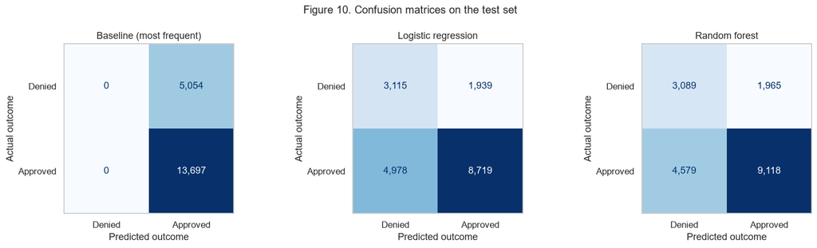

```python
# Create Confusion Matrices for the test set
fig, axes = plt.subplots(1, 3, figsize=(15, 4.3))
for ax, (name, model) in zip(axes, models.items()):
    ConfusionMatrixDisplay.from_estimator(
        model, X_test, y_test, labels=[0, 1], display_labels=["Denied", "Approved"],
        cmap="Blues", colorbar=False, ax=ax, values_format=",")
    ax.set_title(name)
    ax.set_xlabel("Predicted outcome"); ax.set_ylabel("Actual outcome")
    ax.grid(False)
fig.suptitle("Figure 10. Confusion matrices on the test set", fontsize=13)
plt.tight_layout(); plt.show()
```

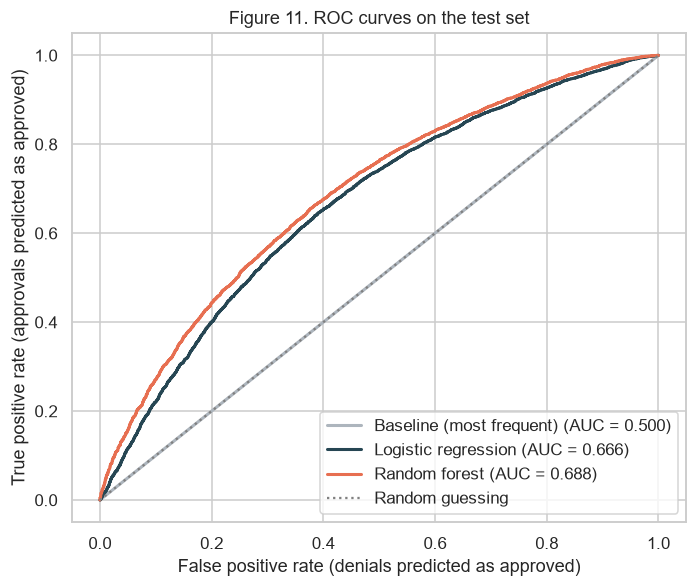

```python
# Create ROC curves for the test set
fig, ax = plt.subplots(figsize=(6.5, 5.5))
colors = {"Baseline (most frequent)": "#adb5bd", "Logistic regression": "#264653", "Random forest": "#e76f51"}
for name, model in models.items():
    fpr, tpr, _ = roc_curve(y_test, model.predict_proba(X_test)[:, 1])
    ax.plot(fpr, tpr, color=colors[name], linewidth=2,
            label=f"{name} (AUC = {results.loc[name, 'ROC-AUC']:.3f})")
ax.plot([0, 1], [0, 1], linestyle=":", color="gray", label="Random guessing")
ax.legend(loc="lower right")
ax.set_title("Figure 11. ROC curves on the test set")
ax.set_xlabel("False positive rate (denials predicted as approved)")
ax.set_ylabel("True positive rate (approvals predicted as approved)")
plt.tight_layout(); plt.show()
```